# ⭐️ Analiza evaluărilor utilizatorilor în magazinul online

**Autor:** Stoian Andrei

## 2. 🔍 Introducere

În această analiză ne propunem să înțelegem cum sunt evaluate produsele de către clienți într-un magazin online.

Obiectivul principal este de a identifica:

- *Cum evoluează evaluările produselor în timp;*
- *Ce categorii de produse sunt cel mai bine sau cel mai slab cotate;*
- *Dacă există diferențe notabile în evaluări în funcție de anul lansării sau categoria produsului.*

Aceste informații sunt utile echipei de marketing și management pentru a:

- *Prioritiza stocurile de produse apreciate;*
- *Îmbunătăți comunicarea pentru categoriile cu evaluări mai slabe;*
- *Înțelege mai bine comportamentul de cumpărare al clienților în funcție de trendurile anuale.*

Analiza se bazează pe date reale dintr-un sistem de comerț online, iar concluziile pot avea aplicații practice în deciziile comerciale.

## 3. 💾 Pregătirea datelor

În această etapă încărcăm datele din fișierul CSV care conține informații despre produsele disponibile în magazinul online.

Vom realiza o privire de ansamblu asupra structurii datasetului:

- Vom afișa primele rânduri;
- Vom verifica tipurile de coloane și dacă există valori lipsă;
- Vom pregăti eventuale coloane noi necesare pentru analiză.

```python
import pandas as pd
import matplotlib.pyplot as plt
import seaborn as sns

df = pd.read_csv("PDV5_02-Task_2-online_store_data.csv")

df.head() # Afisarea primelor 5 randuri
```

|  | product_name | category | price | quantity_in_stock | quantity_sold | brand | rating | num_of_ratings | date_added | color | revenue |
| --- | --- | --- | --- | --- | --- | --- | --- | --- | --- | --- | --- |
| 0 | iPad mini (2021) (64GB, Blue) | Tablets | 499.00 | 266.0 | 185.0 | Apple | 8.75 | 151.0 | 2/2/2022 | blue | 92315.00 |
| 1 | K55 RGB (Red) | Keyboards | 49.99 | 0.0 | 561.0 | Corsair | 8.50 | 455.0 | 8/14/2022 | red | 28044.39 |
| 2 | Fenix 7 (Purple) | Watches | 699.99 | 0.0 | 374.0 | Garmin | 9.20 | 305.0 | 4/20/2022 | purple | 261796.26 |
| 3 | Mate 40 (256GB, Orange) | Smartphones | 899.00 | 182.0 | 615.0 | Huawei | 8.50 | 500.0 | 10/23/2024 | orange | 552885.00 |
| 4 | Rival 600 (Red) | Mice | 79.99 | 35.0 | 698.0 | SteelSeries | 9.25 | 556.0 | 9/29/2020 | red | 55833.02 |

## 4. 🎯 Perspectivă analitică 1 – Valorile extreme ale evaluărilor

Pentru a înțelege cum percep clienții produsele, este esențial să identificăm nota minimă și maximă acordată de utilizatori.  
Aceste valori ne oferă o imagine de ansamblu asupra extremelor din experiența clienților.

Mai jos extragem cele două valori și le prezentăm textual:

```python
print("📈 Nota maxima : " , df["rating"].max())
print("📉 Nota minima : " , df["rating"].min())
```

```
📈 Nota maxima :  9.75
📉 Nota minima :  5.5
```

## 5. 📈 Perspectivă analitică 2 – Evoluția evaluărilor în timp

Această tendință ne poate indica:

- dacă produsele mai recente sunt mai bine sau mai slab primite;
- cum se schimbă satisfacția clienților în funcție de perioada în care un produs este introdus în ofertă.

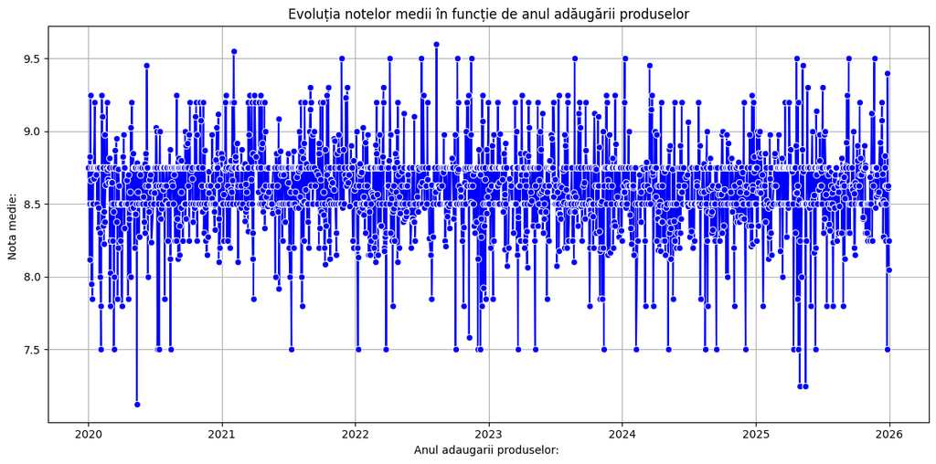

```python
df['date_added'] = pd.to_datetime(df['date_added'], errors='coerce')
df['year_added'] = df['date_added'].dt.year
evolutie = df.groupby('date_added')['rating'].mean().reset_index()

plt.figure(figsize=(12 , 6))
sns.lineplot(data = evolutie , x = "date_added" , y = "rating" , marker="o" , color="blue")

plt.title("Evoluția notelor medii în funcție de anul adăugării produselor")
plt.xlabel("Anul adaugarii produselor: ")
plt.ylabel("Nota medie: ")
plt.grid(True)
plt.tight_layout()
```

## 6. 🗂️ Perspectivă analitică 3 – Diferențele dintre note în funcție de categorii

Pentru a înțelege ce tipuri de produse sunt cele mai apreciate de clienți, analizăm **nota medie pe fiecare categorie** de produse.

Această analiză ne ajută să răspundem la întrebări precum:

- Ce tipuri de produse au avut cel mai mare succes?
- Există categorii unde satisfacția clienților este sub medie?

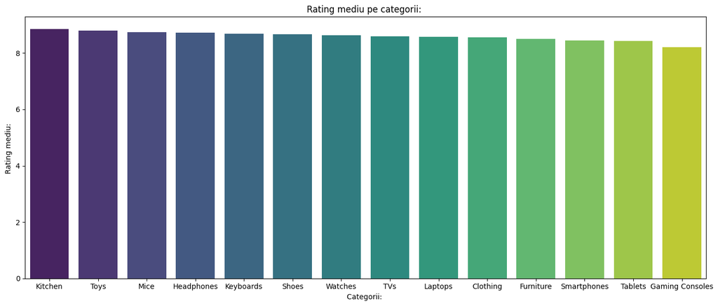

```python
categorii = df.groupby("category")["rating"].mean().reset_index()
categorii = categorii.sort_values(by="rating" , ascending=False)

plt.figure(figsize=(14,6))
sns.barplot(data=categorii , x = "category" , y = "rating" , palette = "viridis")

plt.title("Rating mediu pe categorii: ")
plt.xlabel("Categorii: ")
plt.ylabel("Rating mediu: ")
plt.tight_layout()
plt.show()
```

## 7. 🎯 Reprezentarea vizuală a rezultatelor

Pentru a sprijini concluziile obținute în pașii anteriori, am inclus următoarele grafice care evidențiază vizual tendințele și diferențele observate în date:

✅ Grafic 1: Evoluția notelor medii în timp (linia de tendință)

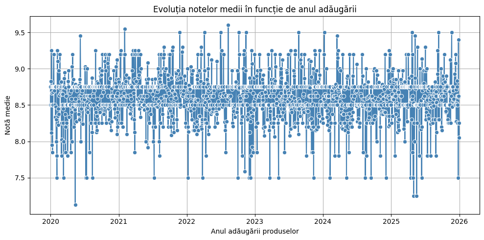

```python
plt.figure(figsize=(10, 5))
sns.lineplot(data=evolutie, x='date_added', y='rating', marker='o', color='steelblue')
plt.title("Evoluția notelor medii în funcție de anul adăugării")
plt.xlabel("Anul adăugării produselor")
plt.ylabel("Notă medie")
plt.grid(True)
plt.tight_layout()
plt.show()
```

✅ Grafic 2: Note medii pe categorii (bar chart orizontal)

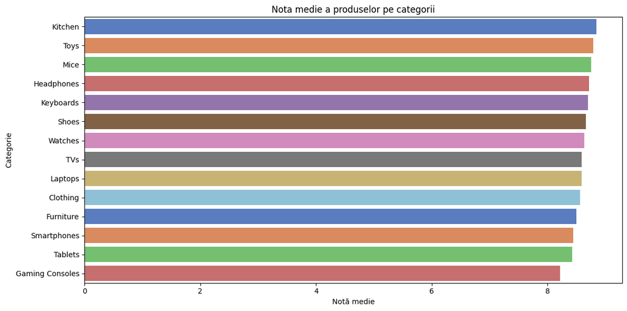

```python
plt.figure(figsize=(12, 6))
sns.barplot(data=categorii, x='rating', y='category', palette='muted')
plt.title("Nota medie a produselor pe categorii")
plt.xlabel("Notă medie")
plt.ylabel("Categorie")
plt.tight_layout()
plt.show()
```

🔍 **Interpretare**: Acest grafic ne permite să comparăm rapid performanța categoriilor. Categoriile din partea de sus au cele mai bune evaluări medii și pot indica produse de succes sau bine poziționate. Categoriile din partea de jos ar putea necesita îmbunătățiri sau investigații suplimentare.

## 8. 🧠 Concluzie

📌 **Implicații**:

- Echipa de marketing poate promova produsele din categoriile de top.
- Achizițiile pot fi optimizate în funcție de trendurile de evaluare.
- Se pot lua decizii mai bune privind retragerea sau îmbunătățirea produselor slab cotate.

## 9. 💬 Reflecție

Această sarcină m-a ajutat să înțeleg mai bine legătura dintre analiza datelor și vizualizare într-un context de afaceri.

🔍 **Ce a fost dificil**:  
Prelucrarea coloanei `date_added` și extragerea anului a necesitat atenție la conversia formatului de dată și la valorile lipsă.

📈 **Ce aș face diferit**:  
Data viitoare aș folosi și un instrument interactiv (ex: Plotly) pentru vizualizări și aș adăuga un filtru per categorie sau an pentru o analiză dinamică.

✅ **Ce a fost interesant**:  
Am observat cum alegerea tipului de grafic poate face o diferență majoră în înțelegerea datelor și în comunicarea eficientă a concluziilor.

Această experiență mi-a consolidat abilitățile de a lucra cu date reale într-un mod orientat către decizii.